# DATA SCIENCE LATAM

UN ESPACIO PARA NUNCA PARAR DE APRENDER!!

Francisco Zambrano Cruz. Mayo 2020.

[figure not shown]

Pre-requisitos: Leer [Gráficas de Series de Tiempo](https://zpio.github.io/datascience/post/Gr%C3%A1ficos_Series_Tiempo_R.html) , [Descomposición de Series de Tiempo](https://zpio.github.io/datascience/post/Descomposicion_series_tiempo.html) , [Suavizado Exponencial](https://zpio.github.io/datascience/post/Suavizado_Exponencial.html)

# Modelos ARIMA

Los modelos ARIMA proporcionan otro enfoque para el pronóstico de series de tiempo. El suavizado exponencial y los modelos ARIMA son los dos enfoques más utilizados para la predicción de series de tiempo, y proporcionan enfoques complementarios al problema. Mientras que los **modelos de suavizado exponencial se basan en una descripción de la tendencia y la estacionalidad en los datos**, los **modelos ARIMA tienen como objetivo describir las autocorrelaciones en los datos**.

Antes de presentar los modelos ARIMA, primero debemos analizar el concepto de estacionariedad y la técnica de diferenciar series temporales.

## 1. Estacionariedad y diferenciación

### Series Temporales Estacionarias

Una **serie temporal estacionaria** es aquella cuyas propiedades no dependen del momento en que se observa la serie. Por lo tanto, las **series temporales con tendencias, o con estacionalidad, no son estacionarias**: la tendencia y la estacionalidad afectarán el valor de la serie temporal en diferentes momentos. Por otro lado, **una serie de ruido blanco es estacionaria**: no importa cuando la observe, debería verse muy similar en cualquier momento.

Algunos casos pueden ser confusos: **una serie temporal con comportamiento cíclico (pero sin tendencia ni estacionalidad) es estacionaria**. Esto se debe a que los ciclos no son de una longitud fija, por lo tanto, antes de observar la serie, no podemos estar seguros de dónde estarán los picos y valles de los ciclos.

En general, **una serie temporal estacionaria no tendrá patrones predecibles a largo plazo**. Las gráficas de tiempo mostrarán que la **serie es aproximadamente horizontal** (aunque es posible algún comportamiento cíclico), con una variación constante.

**Figura 1:** ¿Cuáles de estas series son estacionarias?

(a) precio de las acciones de Google durante 200 días consecutivos;

(b) Cambio diario en el precio de las acciones de Google durante 200 días consecutivos;

(c) Número anual de huelgas en los Estados Unidos;

(d) Ventas mensuales de nuevas casas unifamiliares vendidas en los Estados Unidos;

(e) Precio anual de una docena de huevos en los Estados Unidos (dólares constantes);

(f) Total mensual de cerdos sacrificados en Victoria, Australia;

(g) Total anual de linces atrapados en el distrito del río McKenzie del noroeste de Canadá;

(h) Producción mensual de cerveza australiana;

(i) Producción mensual de electricidad en Australia.

[figure not shown]

La estacionalidad descarta las series (d), (h) e (i). Las tendencias y los niveles cambiantes descartan las series (a), (c), (e), (f) e (i). La varianza creciente también descarta (i). Eso deja solo (b) y (g) como series estacionarias.

A primera vista, los ciclos fuertes en la serie (g) pueden parecer no estacionarios. Pero estos ciclos son aperiódicos: se producen cuando la población de linces se vuelve demasiado grande para el alimento disponible, de modo que dejan de reproducirse y la población cae a un número bajo, luego la regeneración de sus fuentes de alimentos permite que la población vuelva a crecer, y así en. A largo plazo, el momento de estos ciclos no es predecible. Por lo tanto, la serie es estacionaria.

## Diferenciación

En la Figura 1 , tenga en cuenta que el precio de las acciones de Google no era estacionario en el panel (a), pero los **cambios diarios** eran estacionarios en el panel (b). Esto muestra una forma de hacer que una serie temporal no estacionaria sea estacionaria: calcular **las diferencias entre observaciones consecutivas**. Esto se conoce como **diferenciación**.

Las **transformaciones como los logaritmos pueden ayudar a estabilizar la varianza de una serie temporal**. La **diferenciación** puede ayudar a **estabilizar la media** de una serie temporal eliminando los cambios en el nivel de una serie temporal y, por lo tanto, eliminando (o reduciendo) la tendencia y la estacionalidad.

Además de observar el gráfico de tiempo de los datos, el gráfico de ACF también es útil para identificar series de tiempo no estacionarias. Para una **serie de tiempo estacionaria**, el **ACF caerá a cero relativamente rápido**, mientras que el **ACF de datos no estacionarios disminuye lentamente**.

**Figura 2:** El ACF del precio de las acciones de Google (izquierda) y de los cambios diarios en el precio de las acciones de Google (derecha).

[figure not shown]

```r
library(ggplot2)
library(fpp2)
```

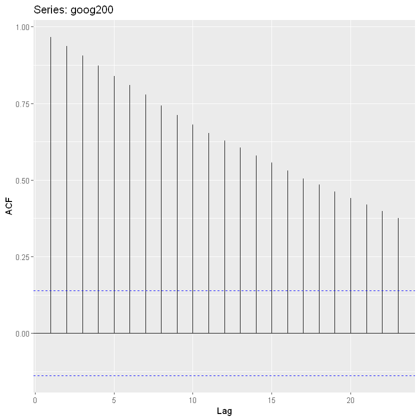

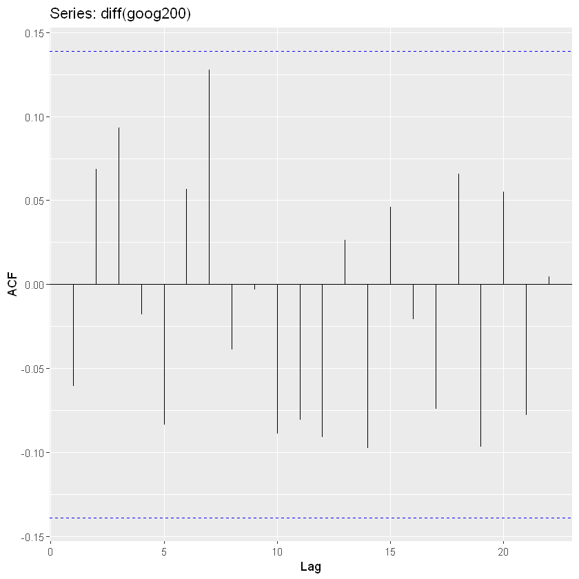

```r
ggAcf(goog200)
ggAcf(diff(goog200))
```

El **ACF del precio diferenciado de las acciones de Google** se parece al de una **serie de ruido blanco**. No hay autocorrelaciones fuera del límite del 95%, y el estadistico Ljung-Box Q tiene un valor p de 0.355. Esto sugiere que el cambio diario en el precio de las acciones de Google es esencialmente una cantidad aleatoria que no está correlacionada con la de los días anteriores.

```r
Box.test(diff(goog200), lag=10, type="Ljung-Box")
```

```
	Box-Ljung test

data:  diff(goog200)
X-squared = 11.031, df = 10, p-value = 0.3551
```

## Random walk model

La serie diferenciada es el cambio entre observaciones consecutivas en la serie original, y puede escribirse como:

$$y'_t = y_t - y_{t-1}$$

Las series diferenciadas solo tendrán T-1 valores, ya que no es posible calcular una diferencia para la primera observación.

Cuando la serie diferenciada es ruido blanco, el modelo de la serie original se puede escribir como: $$y_t - y_{t-1} = \varepsilon_t$$

donde εt denota ruido blanco. Reorganizar esto lleva al modelo de "Random walk": $$y_t = y_{t-1} + \varepsilon_t$$

Los modelos de **Random walk** se usan ampliamente para **datos no estacionarios**, particularmente datos financieros y económicos. Las Random walk generalmente tienen:

- largos períodos de tendencias aparentes hacia arriba o hacia abajo
- cambios repentinos e impredecibles en la dirección.
- Los pronósticos de un modelo de **Random walk** son iguales a la última observación, ya que los movimientos futuros son impredecibles y tienen la misma probabilidad de subir o bajar. Por lo tanto, el modelo de **Random walk** respalda los pronósticos naives.

Un modelo estrechamente relacionado permite que las diferencias tengan una media distinta de cero. Entonces:

$$y_t - y_{t-1} = c + \varepsilon_t\quad\text{or}\quad {y_t = c + y_{t-1} + \varepsilon_t}\: .$$

El valor de c es el promedio de los cambios entre observaciones consecutivas. Si c es positivo, entonces el cambio promedio es un aumento en el valor de yt. Por lo tanto, yt tenderá a desplazarse hacia arriba. Sin embargo, si c es negativo, yt tenderá a la deriva hacia abajo.

## Diferenciación de segundo orden

Ocasionalmente, los datos diferenciados no parecerán estacionarios y puede ser necesario diferenciar los datos por segunda vez para obtener una serie estacionaria:

$$\begin{align*} y''_{t} &= y'_{t} - y'_{t - 1} \\ &= (y_t - y_{t-1}) - (y_{t-1}-y_{t-2})\\ &= y_t - 2y_{t-1} +y_{t-2}. \end{align*}$$

En la práctica, casi nunca es necesario ir más allá de las diferencias de segundo orden.

## Diferenciación estacional

Una diferencia estacional es la diferencia entre una observación y la observación previa de la misma estación. Entonces:

$$y'_t = y_t - y_{t-m}$$

donde m = el número de estaciones. Éstos también se llaman “lag-m differences", ya que restamos la observación después de un retraso de m períodos.

Si los datos diferenciados estacionalmente parecen ser ruido blanco, entonces un modelo apropiado para los datos originales es:

$$y_t = y_{t-m}+\varepsilon_t$$

Los pronósticos de este modelo son iguales a la última observación de la temporada relevante. Es decir, este modelo proporciona pronósticos naives estacionales.

El panel inferior de la Figura 3 muestra las diferencias estacionales del logaritmo de las ventas mensuales para los medicamentos A10 (antidiabéticos) vendidos en Australia. La transformación y la diferenciación han hecho que la serie parezca relativamente estacionaria.

**Figura 3:** Registros y diferencias estacionales de los datos de ventas A10 (antidiabéticos). **Los logaritmos estabilizan la varianza**, mientras que las **diferencias estacionales eliminan la estacionalidad y la tendencia**.

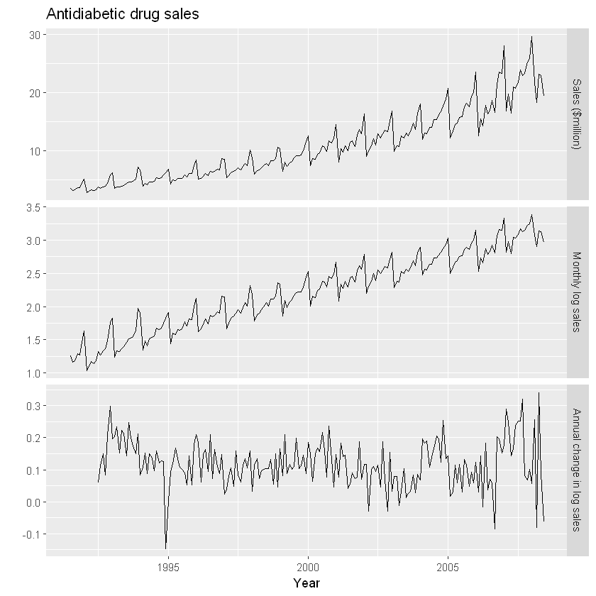

```r
cbind("Sales ($million)" = a10,
      "Monthly log sales" = log(a10),
      "Annual change in log sales" = diff(log(a10),12)) %>%
  autoplot(facets=TRUE) +
    xlab("Year") + ylab("") +
    ggtitle("Antidiabetic drug sales")
```

Para distinguir las **diferencias estacionales** de las **diferencias ordinarias**, a veces nos referimos a las **diferencias ordinarias como "primeras diferencias"**, lo que significa **diferencias en el lag 1**.

A veces es necesario tomar una diferencia estacional y una primera diferencia para obtener datos estacionarios, como se muestra en la Figura 4 . Aquí, los datos se transforman **primero usando logaritmos (segundo panel)**, luego se calculan las **diferencias estacionales (tercer panel)**. Los datos todavía parecen algo no estacionarios, por lo que se calculan muchas otras **primeras diferencias (panel inferior)**.

**Figura 4:** Panel superior: generación neta de electricidad en EE. UU. (Mil millones de kWh). Otros paneles muestran los mismos datos después de la transformación y la diferenciación.

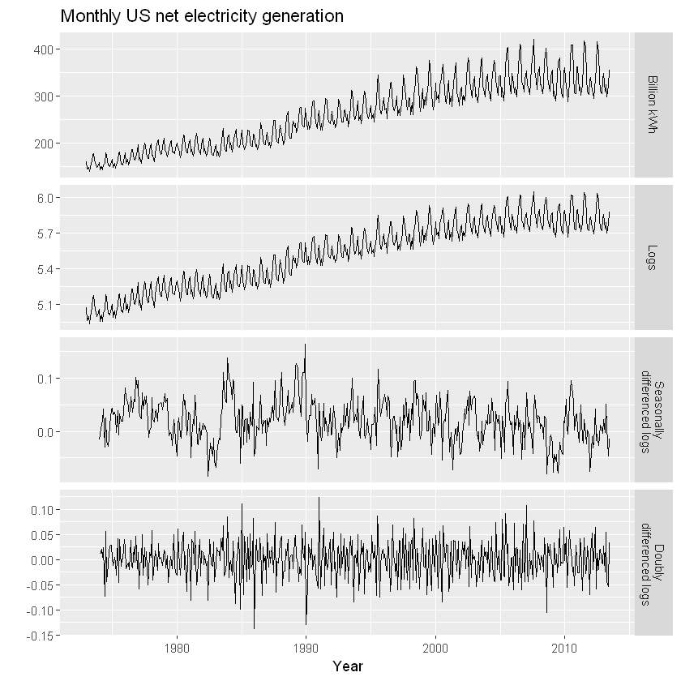

```r
cbind("Billion kWh" = usmelec,
      "Logs" = log(usmelec),
      "Seasonally\n differenced logs" =
        diff(log(usmelec),12),
      "Doubly\n differenced logs" =
        diff(diff(log(usmelec),12),1)) %>%
  autoplot(facets=TRUE) +
    xlab("Year") + ylab("") +
    ggtitle("Monthly US net electricity generation")
```

Hay un grado de subjetividad en la selección de las diferencias a aplicar. Los datos diferenciados estacionalmente en la Figura 3 no muestran un comportamiento sustancialmente diferente de los datos diferenciados estacionalmente en la Figura 4 . En el último caso, podríamos haber decidido detenernos con los datos diferenciados estacionalmente, y no haber hecho una ronda adicional de diferenciación. En el primer caso, podríamos haber decidido que los datos no eran lo suficientemente estacionarios y haber tomado una ronda adicional de diferenciación. A continuación se analizan algunas pruebas formales para la diferenciación, pero siempre hay que tomar algunas decisiones en el proceso de modelado, y diferentes analistas pueden tomar diferentes decisiones.

Si $y'_t = y_t - y_{t-m}$ denota una serie estacionalmente diferenciada, entonces la serie dos veces diferenciada es:

$$\begin{align*} y''_t &= y'_t - y'_{t-1} \\ &= (y_t - y_{t-m}) - (y_{t-1} - y_{t-m-1}) \\ &= y_t -y_{t-1} - y_{t-m} + y_{t-m-1}\: \end{align*}$$

**Cuando se aplican tanto las diferencias estacionales como las primeras, no importa qué se haga primero**: el resultado será el mismo. Sin embargo, **si los datos tienen un patrón estacional fuerte**, recomendamos hacer **primero la diferenciación estacional**, porque las series resultantes a veces serán estacionarias y no habrá necesidad de una primera diferencia adicional. Si la primera diferenciación se realiza primero, aún habrá estacionalidad presente.

Es importante que si se usa la diferenciación, las diferencias sean interpretables. Las primeras diferencias son el cambio entre una observación y la siguiente. Las diferencias estacionales son el cambio entre un año y el siguiente. Es poco probable que otros retrasos tengan mucho sentido interpretable y deben evitarse.

### Pruebas de raíz unitaria

**Una forma de determinar de manera más objetiva si se requiere la diferenciación es usar una prueba de raíz unitaria**. Estas son pruebas de hipótesis estadísticas de estacionariedad diseñadas para determinar si se requiere diferenciación.

Hay disponibles varias pruebas de raíz unitaria, que se basan en supuestos diferentes y pueden dar lugar a respuestas conflictivas. En nuestro análisis, utilizamos la prueba **Kwiatkowski-Phillips-Schmidt-Shin (KPSS)** (Kwiatkowski, Phillips, Schmidt y Shin, 1992 ) . En esta prueba, la **hipótesis nula es que los datos son estacionarios**, y buscamos evidencia de que la hipótesis nula sea falsa. En consecuencia, los valores **p pequeños (p. Ej., Menos de 0.05) sugieren que se requiere diferenciación**. La prueba se puede calcular utilizando la funcion ur.kpss() del paquete urca.

Por ejemplo, apliquémoslo a los datos de precios de acciones de Google.

```r
library(urca)
goog %>% ur.kpss() %>% summary()
```

```
#######################
# KPSS Unit Root Test #
#######################

Test is of type: mu with 7 lags.

Value of test-statistic is: 10.7223

Critical value for a significance level of:
                10pct  5pct 2.5pct  1pct
critical values 0.347 0.463  0.574 0.739
```

El estadístico de prueba es mucho mayor que el valor crítico del 1%, lo que indica que la hipótesis nula es rechazada. Es decir, los datos no son estacionarios. Podemos diferenciar los datos y aplicar la prueba nuevamente.

```r
goog %>% diff() %>% ur.kpss() %>% summary()
```

```
#######################
# KPSS Unit Root Test #
#######################

Test is of type: mu with 7 lags.

Value of test-statistic is: 0.0324

Critical value for a significance level of:
                10pct  5pct 2.5pct  1pct
critical values 0.347 0.463  0.574 0.739
```

Esta vez, el estadístico de prueba es pequeño y está dentro del rango que esperaríamos para los datos estacionarios (0.0324 < 0.463 ) . Entonces podemos concluir que los datos diferenciados son estacionarios.

La función lleva a cabo este proceso de usar una secuencia de pruebas KPSS para determinar el número apropiado de primeras diferencias ndiffs().

```r
ndiffs(goog)
```

1

Como vimos en las pruebas de KPSS anteriores, se requiere una diferencia para que los datos goog sean estacionarios.

Una función similar para determinar si se requiere diferenciación estacional es la nsdiffs() que utiliza la medida de la fuerza estacional para determinar el número apropiado de diferencias estacionales requeridas. No se sugieren diferencias estacionales si FS<0.64 de lo contrario, se sugiere una diferencia estacional.

Podemos aplicar nsdiffs()a los datos de electricidad mensuales registrados en los EE. UU.

```r
usmelec %>% log() %>% nsdiffs()
```

1

```r
usmelec %>% log() %>% diff(lag=12) %>% ndiffs()
```

1

El operador backward shift B es útil cuando se trabaja con retrasos de series de tiempo: $B y_{t} = y_{t - 1} \: $ (Algunas referencias usan L para "lag" en lugar de B para "backward".) En otras palabras, B, operando en yt, tiene el efecto de desplazar los datos hacia atrás un período.

## 2. Modelos autorregresivos

En un modelo de regresión múltiple, pronosticamos la variable de interés utilizando una combinación lineal de predictores. En un **modelo de autorregresión, pronosticamos la variable de interés utilizando una combinación lineal de valores pasados de la variable**. El término auto-regresión indica que es una regresión de la variable contra sí misma.

Por lo tanto, un modelo autorregresivo de orden p Se puede escribir como:

$$y_{t} = c + \phi_{1}y_{t-1} + \phi_{2}y_{t-2} + \dots + \phi_{p}y_{t-p} + \varepsilon_{t}$$

donde εt es ruido blanco. Esto es como una regresión múltiple pero con valores rezagados de yt como predictores. Nos referimos a esto como un modelo AR(p), un modelo autorregresivo de orden p.

Los modelos autorregresivos son notablemente flexibles para manejar una amplia gama de patrones de series temporales diferentes. Las dos series de la Figura 5 muestran series de un modelo AR (1) y un modelo AR (2). Cambiando los parámetros ϕ1,...,ϕp da como resultado diferentes patrones de series de tiempo. La varianza del término de error εt solo cambiará la escala de la serie, no los patrones.

Figure 5: Dos ejemplos de datos de modelos autorregresivos con diferentes parámetros. Izquierda: AR(1) with $y_t = 18 -0.8y_{t-1} + \varepsilon_t$. Derecha: AR(2) con $y_t = 8 + 1.3y_{t-1}-0.7y_{t-2}+\varepsilon_t$. En ambos casos, εt se distribuye normalmente ruido blanco con media cero y varianza uno.

[figure not shown]

Para un modelo AR (1):

- cuando ϕ1=0, yt es equivalente al ruido blanco;
- cuando ϕ1=1 y c=0, yt es equivalente a un random walk;
- cuando ϕ1=1 y c≠0, yt es equivalente a un random walk with drift;
- cuando ϕ1<0, yt tiende a oscilar alrededor de la media.

Normalmente restringimos los modelos autorregresivos a datos estacionarios, en cuyo caso se requieren algunas restricciones en los valores de los parámetros.

Para un modelo AR (1): -1 < ϕ1 < 1.

Para un modelo AR (2): -1 < ϕ2 <1, ϕ1 + ϕ2 < 1, ϕ2 - ϕ1 < 1.

Cuando p≥3, las restricciones son mucho más complicadas. R se encarga de estas restricciones al estimar un modelo.

## 3. Modelos de media móvil

En lugar de usar valores pasados de la variable de pronóstico en una regresión, un **modelo de promedio móvil usa errores de pronóstico pasados en un modelo similar a la regresión.**

$$y_{t} = c + \varepsilon_t + \theta_{1}\varepsilon_{t-1} + \theta_{2}\varepsilon_{t-2} + \dots + \theta_{q}\varepsilon_{t-q}$$

donde εt es ruido blanco. Nos referimos a esto como un modelo MA (q) , un modelo de media móvil de orden q. Por supuesto, no observamos los valores de εt, por lo que no es realmente una regresión en el sentido habitual.

Observe que cada valor de yt puede considerarse como un promedio móvil ponderado de los últimos errores de pronóstico. Sin embargo, los modelos de promedio móvil no deben confundirse con el suavizado del promedio móvil. Se usa un modelo de promedio móvil para pronosticar valores futuros, mientras que el suavizado de promedio móvil se usa para estimar el ciclo de tendencia de valores pasados.

**Figura 6:** Dos ejemplos de datos de modelos de promedio móvil con diferentes parámetros. Izquierda: MA (1) con $y_t = 20 + \varepsilon_t + 0.8\varepsilon_{t-1}$. Derecha: MA(2) with $y_t = \varepsilon_t- \varepsilon_{t-1}+0.8\varepsilon_{t-2}$, En ambos casos, εt normalmente se distribuye ruido blanco con media cero y varianza uno.

[figure not shown]

La Figura 6 muestra algunos datos de un modelo MA (1) y un modelo MA (2). Cambiar los parámetros θ1,...,θq da como resultado diferentes patrones de series de tiempo. Al igual que con los modelos autorregresivos, la varianza del término de error εt solo cambiará la escala de la serie, no los patrones.

Es posible escribir cualquier AR estacionario (p) modelo como un MA (∞) model. Por ejemplo, usando la sustitución repetida, podemos demostrar esto para un modelo AR (1):

$$\begin{align*} y_t &= \phi_1y_{t-1} + \varepsilon_t\\ &= \phi_1(\phi_1y_{t-2} + \varepsilon_{t-1}) + \varepsilon_t\\ &= \phi_1^2y_{t-2} + \phi_1 \varepsilon_{t-1} + \varepsilon_t\\ &= \phi_1^3y_{t-3} + \phi_1^2\varepsilon_{t-2} + \phi_1 \varepsilon_{t-1} + \varepsilon_t\\ &\text{etc.} \end{align*}$$

Proporcionado -1<ϕ1<1, el valor de $\phi_1^k$ se hará más pequeño como k se hace más grande. Entonces eventualmente obtenemos

$$y_t = \varepsilon_t + \phi_1 \varepsilon_{t-1} + \phi_1^2 \varepsilon_{t-2} + \phi_1^3 \varepsilon_{t-3} + \cdots$$

un proceso MA (∞).

El resultado inverso es válido si imponemos algunas restricciones en los parámetros de MA. Entonces el modelo MA se llama invertible. Es decir, podemos escribir cualquier MA invertible ( q) proceso como un proceso AR ( ∞). Los modelos invertibles no se presentan simplemente para permitirnos convertir de modelos MA a modelos AR. También tienen algunas propiedades matemáticas deseables.

Las restricciones de invertibilidad para otros modelos son similares a las restricciones de estacionariedad.

- Para un modelo MA (1): -1<θ1<1.
- Para un modelo MA (2): -1<θ2<1, θ2+θ1>-1, θ1-θ2<1.

Condiciones más complicadas se mantienen para q≥3. Nuevamente, R se encargará de estas limitaciones al estimar los modelos.

## 4. Modelos ARIMA no estacionales

Si combinamos la diferenciación con autorregresión y un modelo de promedio móvil, obtenemos un modelo ARIMA no estacional. ARIMA es un acrónimo de **AutoRegressive Integrated Moving Average** (en este contexto, "integración" es lo contrario de la diferenciación). El modelo completo se puede escribir como

$$\begin{equation} y'_{t} = c + \phi_{1}y'_{t-1} + \cdots + \phi_{p}y'_{t-p} + \theta_{1}\varepsilon_{t-1} + \cdots + \theta_{q}\varepsilon_{t-q} + \varepsilon_{t}, \tag{1} \end{equation}$$

donde $y'_{t}$ es la serie diferenciada (puede haber sido diferenciada más de una vez). Los "predictores" en el lado derecho incluyen ambos valores rezagados de yt y errores rezagados. Llamamos a esto un ARIMA (p,d,q), donde:

- p= orden de la parte autorregresiva;
- d= grado de primera diferencia involucrada;
- q= orden de la parte media móvil.

Las mismas condiciones de estacionariedad e invertibilidad que se usan para los modelos autorregresivos y de promedio móvil también se aplican a un modelo ARIMA.

Muchos de los modelos que ya hemos discutido son casos especiales del modelo ARIMA, como se muestra en la Tabla 1.

- White noise = ARIMA(0,0,0)
- Random walk = ARIMA(0,1,0) with no constant
- Random walk with drift = ARIMA(0,1,0) with a constant
- Autoregression = ARIMA(p,0,0)
- Moving average = ARIMA(0,0,q)

Una vez que comenzamos a combinar componentes de esta manera para formar modelos más complicados, es mucho más fácil trabajar con la notación de retroceso. Por ejemplo, la ecuación (1) se puede escribir en notación de backshift como:

$$\begin{equation} \tag{2} \begin{array}{c c c c} (1-\phi_1B - \cdots - \phi_p B^p) & (1-B)^d y_{t} &= &c + (1 + \theta_1 B + \cdots + \theta_q B^q)\varepsilon_t\\ {\uparrow} & {\uparrow} & &{\uparrow}\\ \text{AR($p$)} & \text{$d$ differences} & & \text{MA($q$)}\\ \end{array} \end{equation}$$

R utiliza una parametrización ligeramente diferente:

$$\begin{equation} \tag{3} (1-\phi_1B - \cdots - \phi_p B^p)(y_t' - \mu) = (1 + \theta_1 B + \cdots + \theta_q B^q)\varepsilon_t, \end{equation}$$

donde $y_t' = (1-B)^d y_t$ y μ es la media de $y_t'$.

$c = \mu(1-\phi_1 - \cdots - \phi_p )$

Seleccionar valores apropiados para p, d y q puede ser difícil. Sin embargo, la auto.arima() función en R lo hará automáticamente.

**Gasto de consumo de los Estados Unidos**

La **Figura 7** muestra los cambios porcentuales trimestrales en el gasto de consumo de los Estados Unidos. Aunque es una serie trimestral, no parece haber un patrón estacional, por lo que ajustaremos un modelo ARIMA no estacional.

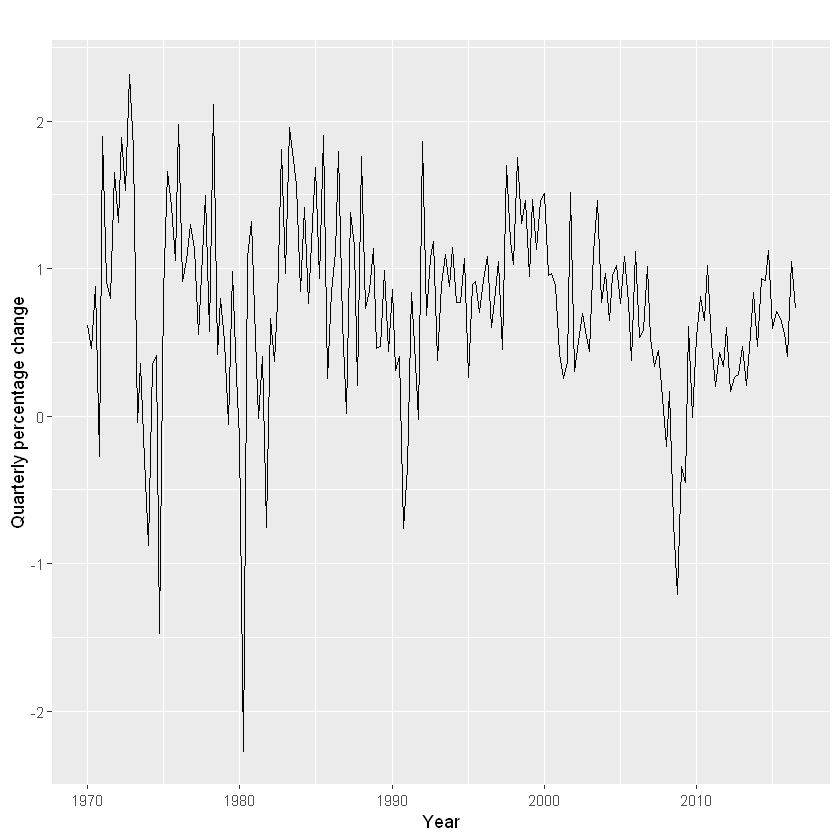

```r
#FIGURA 7

autoplot(uschange[,"Consumption"]) +
  xlab("Year") + ylab("Quarterly percentage change")
```

El siguiente código R se utilizó para seleccionar un modelo automáticamente.

```r
fit <- auto.arima(uschange[,"Consumption"], seasonal=FALSE)
fit
```

```
Series: uschange[, "Consumption"]
ARIMA(1,0,3) with non-zero mean

Coefficients:
         ar1      ma1     ma2     ma3    mean
      0.5885  -0.3528  0.0846  0.1739  0.7454
s.e.  0.1541   0.1658  0.0818  0.0843  0.0930

sigma^2 estimated as 0.3499:  log likelihood=-164.81
AIC=341.61   AICc=342.08   BIC=361
```

[output not shown]

$$c= 0.745 \times (1 - 0.589) = 0.307$$

εt es ruido blanco con una desviación estándar de $0.592 = \sqrt{0.350}$. Los pronósticos del modelo se muestran en la **Figura 8:**

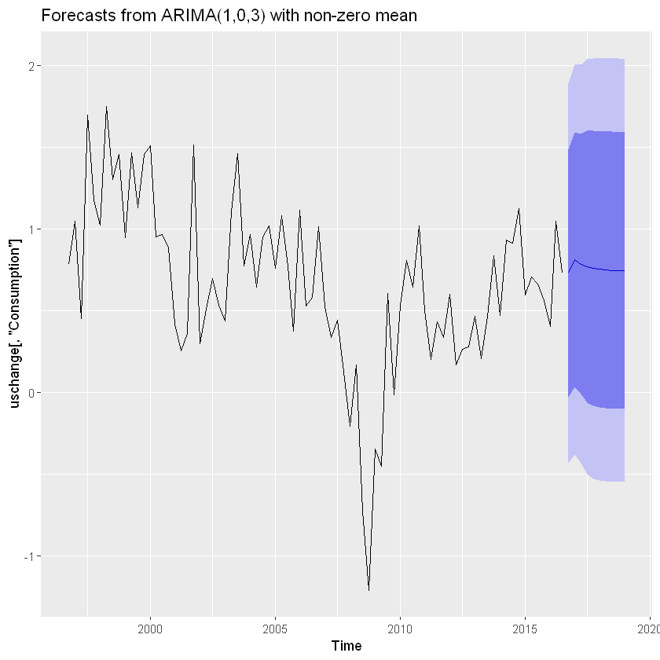

```r
#FIGURA 8

fit %>% forecast(h=10) %>% autoplot(include=80)
```

### Comprender los modelos ARIMA

La función auto.arima() es útil, pero cualquier cosa automatizada puede ser un poco peligrosa, y vale la pena entender algo sobre el comportamiento de los modelos, incluso cuando confía en un procedimiento automático para elegir el modelo para usted.

La constante c tiene un efecto importante en los pronósticos a largo plazo obtenidos de estos modelos.

- Si c=0 y d=0, las previsiones a largo plazo irán a cero.
- Si c=0 y d=1, las previsiones a largo plazo irán a una constante distinta de cero.
- Si c=0 y d=2, las previsiones a largo plazo seguirán una línea recta.
- Si c≠0 y d=0, los pronósticos a largo plazo irán a la media de los datos.
- Si c≠0 y d=1, las previsiones a largo plazo seguirán una línea recta.
- Si c≠0 y d=2, las previsiones a largo plazo seguirán una tendencia cuadrática.

**El valor de d también tiene un efecto en los intervalos de predicción: cuanto mayor sea el valor de d, más rápidamente aumentan los intervalos de predicción en tamaño**. Para d=0, la desviación estándar de pronóstico a largo plazo irá a la desviación estándar de los datos históricos, por lo que los intervalos de predicción serán esencialmente los mismos.

Este comportamiento se ve en la Figura 8 donde d=0 y c≠0. En esta figura, los intervalos de predicción son casi los mismos para los últimos horizontes de pronóstico, y los pronósticos puntuales son iguales a la media de los datos.

**El valor de p es importante si los datos muestran ciclos**. Para obtener **pronósticos cíclicos, es necesario tener p≥2**, junto con algunas condiciones adicionales en los parámetros. Para un modelo AR (2), el comportamiento cíclico ocurre si $\phi_1^2+4\phi_2<0$ . En ese caso, el período promedio de los ciclos es:

$$\frac{2\pi}{\text{arc cos}(-\phi_1(1-\phi_2)/(4\phi_2))}$$

### Graficas ACF y PACF

Por lo general, no es posible saber, simplemente a partir de una gráfica de tiempo, qué valores de p y q son apropiados para los datos. Sin embargo, a veces es posible utilizar el gráfico ACF, y el gráfico PACF estrechamente relacionado, para determinar los valores apropiados para p y q.

Recuerde que un gráfico ACF muestra las autocorrelaciones que miden la relación entre yt y yt-k para diferentes valores de k. Ahora si yt y yt-1 están correlacionados, entonces yt-1 y yt-2 también debe estar correlacionado. Sin embargo, yt y yt-2 podría estar correlacionado, simplemente porque ambos están conectados a yt-1, cualquier información nueva contenida en yt-2 que podría usarse para pronosticar yt.

Para superar este problema, podemos usar **autocorrelaciones parciales**. Estos miden la relación entre yt y yt-k después de eliminar los efectos de los lags 1,2,3,...,k-1. Entonces, la primera autocorrelación parcial es idéntica a la primera autocorrelación, porque no hay nada entre ellas para eliminar. Cada autocorrelación parcial se puede estimar como el último coeficiente en un modelo autorregresivo. Específicamente, αk, El kth coeficiente de autocorrelación parcial es igual a la estimación de ϕk en un AR (k) modelo. En la práctica, existen algoritmos más eficientes para calcular αk que se ajustan a todas estas autorregresiones, pero dan los mismos resultados.

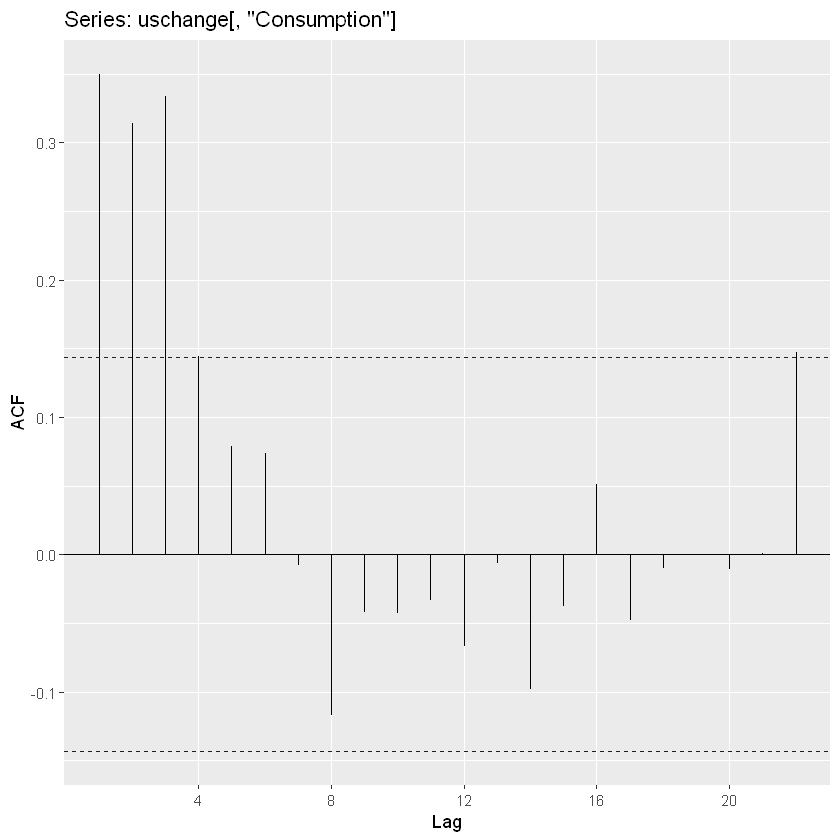

```r
#FIGURA 9

ggAcf(uschange[,"Consumption"])
```

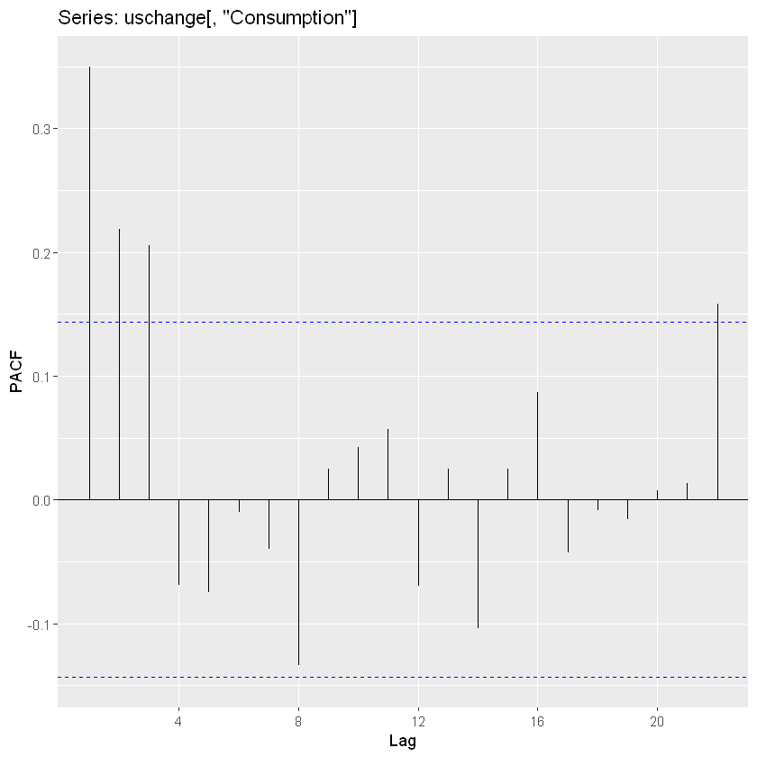

```r
#FIGURA 10

ggPacf(uschange[,"Consumption"])
```

Si los datos son de un ARIMA ( p, d, 0) o ARIMA (0, d, q), entonces los gráficos ACF y PACF pueden ser útiles para determinar el valor de p o q. Si p y q son positivos, entonces las gráficas no ayudan a encontrar valores adecuados de p y q.

Los datos pueden seguir un modelo ARIMA ( p, d, 0) si los gráficos ACF y PACF de los datos diferenciados muestran los siguientes patrones:

- el ACF es exponencialmente decadente o sinusoidal;
- hay un pico significativo en el retraso p en el PACF, pero ninguno más allá del retraso p.

Los datos pueden seguir un ARIMA (0, d, q) si los gráficos ACF y PACF de los datos diferenciados muestran los siguientes patrones:

- el PACF es exponencialmente decadente o sinusoidal;
- hay un pico significativo en el retraso q en el ACF, pero ninguno más allá del retraso q.

En la Figura ACF, vemos que hay tres picos, seguidos por un pico casi significativo en el rezago 4. En el PACF, hay tres picos significativos, y luego no hay picos significativos después (aparte de uno justo fuera de los límites en retraso 22). Podemos ignorar un pico significativo en cada gráfico si está fuera de los límites, y no en los primeros retrasos. Después de todo, la probabilidad de que un pico sea significativo por casualidad es de aproximadamente uno de cada veinte, y estamos trazando 22 picos en cada gráfico. El patrón en los primeros tres picos es lo que esperaríamos de un ARIMA (3,0,0), ya que el PACF tiende a disminuir. Entonces, en este caso, el ACF y el PACF nos llevan a pensar que un modelo ARIMA (3,0,0) podría ser apropiado.

```r
(fit2 <- Arima(uschange[,"Consumption"], order=c(3,0,0)))
```

```
Series: uschange[, "Consumption"]
ARIMA(3,0,0) with non-zero mean

Coefficients:
         ar1     ar2     ar3    mean
      0.2274  0.1604  0.2027  0.7449
s.e.  0.0713  0.0723  0.0712  0.1029

sigma^2 estimated as 0.3494:  log likelihood=-165.17
AIC=340.34   AICc=340.67   BIC=356.5
```

Este modelo es en realidad un poco mejor que el modelo identificado por auto.arima()(con un valor AICc de 340.67 en comparación con 342.08). La auto.arima() no encontró este modelo porque no considera todos los modelos posibles en su búsqueda. Puedes hacer que trabaje más duro usando los argumentos stepwise=FALSE y approximation=FALSE:

```r
(fit3 <- auto.arima(uschange[,"Consumption"], seasonal=FALSE,
  stepwise=FALSE, approximation=FALSE))
```

```
Series: uschange[, "Consumption"]
ARIMA(3,0,0) with non-zero mean

Coefficients:
         ar1     ar2     ar3    mean
      0.2274  0.1604  0.2027  0.7449
s.e.  0.0713  0.0723  0.0712  0.1029

sigma^2 estimated as 0.3494:  log likelihood=-165.17
AIC=340.34   AICc=340.67   BIC=356.5
```

## 5. Criterios de información

El Criterio de información (AIC) de Akaike, que fue útil para seleccionar predictores de regresión, también es útil para determinar el orden de un modelo ARIMA. Se puede escribir como.

$$\text{AIC} = -2 \log(L) + 2(p+q+k+1)$$

donde L es la probabilidad de los datos, k=1 si c≠0 y k=0 si c=0. Tenga en cuenta que el último término entre paréntesis es el número de parámetros en el modelo (incluyendo σ2, la varianza de los residuos).

Para los modelos ARIMA, el AIC corregido se puede escribir como:

$$\text{AICc} = \text{AIC} + \frac{2(p+q+k+1)(p+q+k+2)}{T-p-q-k-2}$$

y el criterio de información bayesiano se puede escribir como:

$$\text{BIC} = \text{AIC} + [\log(T)-2](p+q+k+1)$$

Los buenos modelos se obtienen minimizando el AIC, AICc o BIC. Nuestra preferencia es usar el AICc.

Es importante tener en cuenta que estos criterios de información tienden a no ser buenas guías para seleccionar el orden apropiado de diferenciación ( d ) de un modelo, pero si para seleccionar los valores de p y q. Esto se debe a que la diferenciación cambia los datos en los que se calcula la probabilidad, lo que hace que los valores de AIC entre modelos con diferentes órdenes de diferenciación no sean comparables. Entonces necesitamos usar algún otro enfoque para elegir d, y luego podemos usar el AICc para seleccionar py q.

## 6. ARIMA en R

### Como funciona auto.arima()

La función auto.arima() en R utiliza una variación del algoritmo Hyndman-Khandakar (Hyndman & Khandakar, 2008 ) , que combina pruebas de raíz unitaria, minimización de AICc y MLE para obtener un modelo ARIMA. Los argumentos para auto.arima() proporcionan muchas variaciones en el algoritmo. Lo que se describe aquí es el comportamiento predeterminado.

**Algoritmo Hyndman-Khandakar para el modelado automático ARIMA**

1. El número de diferencias 0≤d≤2 se determina usando pruebas repetidas de KPSS.
2. Los valores de p y q se eligen minimizando el AICc después de diferenciar los datos d veces. En lugar de considerar todas las combinaciones posibles de p y q, el algoritmo utiliza una búsqueda por pasos para atravesar el espacio modelo.

   2.a. Se equipan cuatro modelos iniciales:
   - ARIMA (0,d,0),
   - ARIMA (2,d,2),
   - ARIMA (1,d,0),
   - ARIMA (0,d,1).

     Se incluye una constante a menos que d=2. Si d≤1, también se instala un modelo adicional:
   - ARIMA (0,d,0) sin una constante

   2.b. El mejor modelo (con el valor AICc más pequeño) ajustado en el paso (a) está configurado para ser el "modelo actual".

   2.c. Se consideran variaciones sobre el modelo actual:
   - variar p y/o q del modelo actual por ±1;
   - incluir/excluir c del modelo actual
   - El mejor modelo considerado hasta ahora (ya sea el modelo actual o una de estas variaciones) se convierte en el nuevo modelo actual.

   2.d. Repite el paso 2 (c) hasta que no se encuentre un AICc más bajo.

El procedimiento predeterminado utiliza algunas aproximaciones para acelerar la búsqueda. Estas aproximaciones se pueden evitar con el argumento approximation=FALSE. Es posible que no se encuentre el modelo mínimo de AICc debido a estas aproximaciones o al uso de un procedimiento paso a paso. Se buscará un conjunto mucho más grande de modelos si se usa stepwise=FALSE.

### Elegir tu propio modelo

Si desea elegir el modelo usted mismo, use la función Arima() en R. Hay otra función arima()en R que también se ajusta a un modelo ARIMA. Sin embargo, no permite la constante c a menos que d=0, y no devuelve todo lo necesario para que otras funciones del paquete de pronóstico funcionen. Finalmente, no permite que el modelo estimado se aplique a nuevos datos (lo cual es útil para verificar la precisión del pronóstico). En consecuencia, se recomienda que se use Arima() en su lugar.

### Procedimiento de modelado

Al ajustar un modelo ARIMA a un conjunto de datos de series temporales (no estacionales), el siguiente procedimiento proporciona un enfoque general útil.

- Trace los datos e identifique cualquier observación inusual.
- Si es necesario, transforme los datos (usando una transformación Box-Cox) para estabilizar la varianza.
- Si los datos no son estacionarios, tome las primeras diferencias de los datos hasta que los datos sean estacionarios.
- Examine el ACF / PACF: es un ARIMA ( p,d,0) o ARIMA ( 0,d,q) modelo apropiado?
- Pruebe los modelos elegidos y use el AICc para buscar un modelo mejor.
- Verifique los residuos de su modelo elegido trazando el ACF de los residuos y haciendo una prueba de resumen de los residuos. Si no parecen ruido blanco, pruebe con un modelo modificado.
- Una vez que los residuos se vean como ruido blanco, calcule los pronósticos.

**Ejemplo: pedidos de equipos eléctricos ajustados estacionalmente**

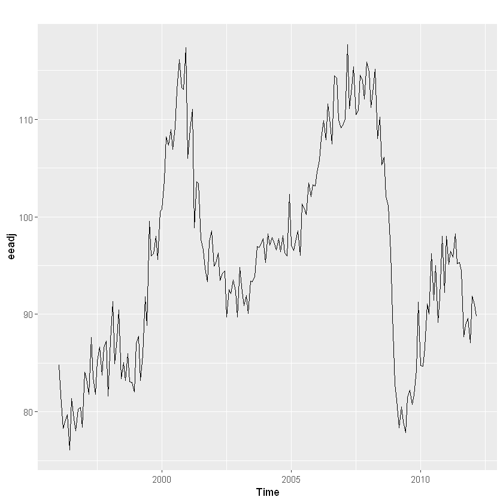

```r
elecequip %>% stl(s.window='periodic') %>% seasadj() -> eeadj
autoplot(eeadj)
```

1. El diagrama de tiempo muestra algunos cambios repentinos, particularmente la gran caída en 2008/2009. Estos cambios se deben al entorno económico mundial. De lo contrario, no hay nada inusual en el diagrama de tiempo y parece que no hay necesidad de hacer ningún ajuste de datos.
2. No hay evidencia de cambios en la varianza, por lo que no haremos una transformación de Box-Cox.
3. Los datos son claramente no estacionarios, ya que la serie se desplaza hacia arriba y hacia abajo durante largos períodos. En consecuencia, tomaremos una primera diferencia de los datos. Los datos diferenciados se muestran en la Figura 13 . Estos parecen estacionarios, por lo que no consideraremos más diferencias.

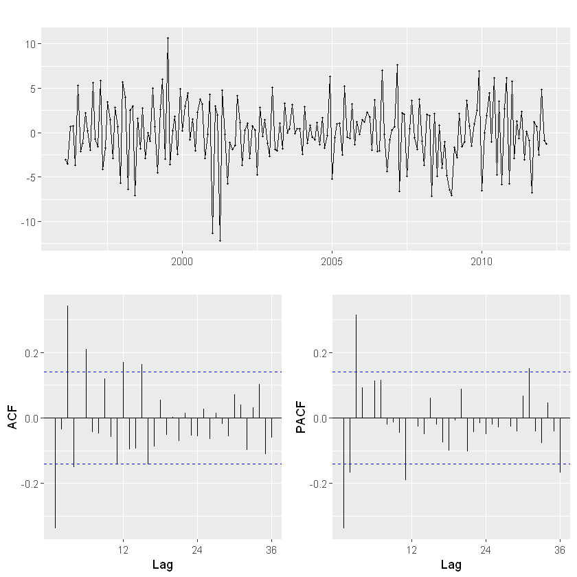

```r
#FIGURA 13

eeadj %>% diff() %>% ggtsdisplay(main="")
```

1. El PACF que se muestra en la Figura sugiere un modelo AR (3). Entonces, un modelo candidato inicial es un ARIMA (3,1,0). No hay otros modelos candidatos obvios.
2. Ajustamos un modelo ARIMA (3,1,0) junto con variaciones que incluyen ARIMA (4,1,0), ARIMA (2,1,0), ARIMA (3,1,1), etc. De estos, el ARIMA (3,1,1) tiene un valor AICc ligeramente menor.

```r
(fit <- Arima(eeadj, order=c(3,1,1)))
```

```
Series: eeadj
ARIMA(3,1,1)

Coefficients:
         ar1     ar2     ar3      ma1
      0.0044  0.0916  0.3698  -0.3921
s.e.  0.2201  0.0984  0.0669   0.2426

sigma^2 estimated as 9.577:  log likelihood=-492.69
AIC=995.38   AICc=995.7   BIC=1011.72
```

1. El gráfico ACF de los residuos del modelo ARIMA (3,1,1) muestra que todas las autocorrelaciones están dentro de los límites del umbral, lo que indica que los residuos se comportan como el ruido blanco. Una prueba de portmanteau devuelve un valor p grande, lo que también sugiere que los residuos son ruido blanco.

```
	Ljung-Box test

data:  Residuals from ARIMA(3,1,1)
Q* = 24.034, df = 20, p-value = 0.2409

Model df: 4.   Total lags used: 24
```

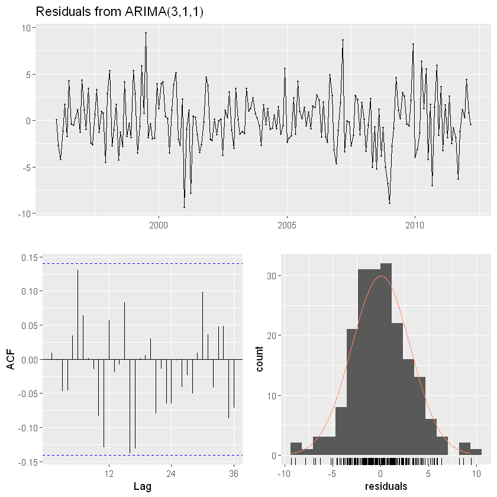

```r
checkresiduals(fit)
```

1. Los pronósticos del modelo elegido se muestran en la Figura siguiente:

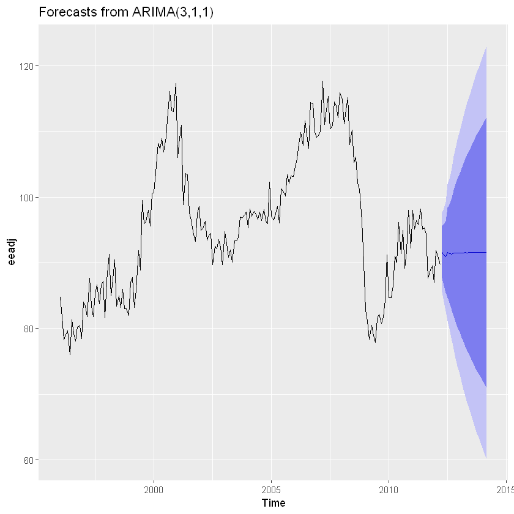

```r
autoplot(forecast(fit))
```

Si hubiéramos utilizado el algoritmo automatizado, habríamos obtenido un modelo ARIMA (3,1,0) utilizando la configuración predeterminada, pero el modelo ARIMA (3,1,1) si lo hubiéramos establecido approximation=FALSE.

Por defecto, la función Arima() establece c=μ=0 cuando d>0 y proporciona una estimación de μ cuando d=0. Estará cerca de la media muestral de la serie temporal, pero generalmente no es idéntica a ella, ya que la media muestral no es la estimación de máxima probabilidad cuando p+q>0.

El argumento include.mean solo tiene efecto cuando d=0 y es TRUE por defecto. El ajuste include.mean=FALSE forzará μ=c=0.

El argumento include.drift permite μ≠0 cuando d=1. Para d>1, no se permite ninguna constante ya que una tendencia de orden cuadrático o superior es particularmente peligrosa cuando se pronostica. El parámetro μ se llama "drift" en la salida R cuando d=1.

También hay un argumento include.constant que, si TRUE, se establecerá include.mean=TRUE si d=0 y include.drift=TRUE cuando d=1. Si include.constant=FALSE, ambos include.meany include.drift se establecerán en FALSE. Si include.constant se utiliza, los valores de include.mean=TRUE y include.drift=TRUE se ignoran.

La función auto.arima() automatiza la inclusión de una constante. Por defecto, para d=0 o d=1, se incluirá una constante si mejora el valor de AICc; para d>1 la constante siempre se omite. Si allowdrift=FALSE se especifica, entonces la constante solo se permite cuando d=0.

## 5. Modelos ARIMA estacionales

Hasta ahora, hemos restringido nuestra atención a los datos no estacionales y los modelos ARIMA no estacionales. Sin embargo, los modelos ARIMA también son capaces de modelar una amplia gama de datos estacionales.

Un modelo estacional ARIMA se forma al incluir términos estacionales adicionales en los modelos ARIMA que hemos visto hasta ahora. Está escrito de la siguiente manera:

ARIMA $(p, d, q)$ PARTE NO ESTACIONAL Y $(P, D, Q)_{m}$ PARTE ESTACIONAL

donde m=Número de observaciones por año. Utilizamos la notación en mayúsculas para las partes estacionales del modelo y la notación en minúsculas para las partes no estacionales del modelo.

La parte estacional del modelo consiste en términos que son similares a los componentes no estacionales del modelo, pero que implican retrocesos del período estacional. Por ejemplo, un ARIMA (1,1,1) (1,1,1) 4 (sin una constante) es para datos trimestrales ( m=4), y se puede escribir como:

$$(1 - \phi_{1}B)~(1 - \Phi_{1}B^{4}) (1 - B) (1 - B^{4})y_{t} = (1 + \theta_{1}B)~ (1 + \Theta_{1}B^{4})\varepsilon_{t}$$

Los términos estacionales adicionales simplemente se multiplican por los términos no estacionales.

### ACF / PACF

La parte estacional de un modelo AR o MA se verá en los rezagos estacionales de PACF y ACF. Por ejemplo, un ARIMA (0,0,0) (0,0,1)12 el modelo mostrará:

- un pico en el rezago 12 en el ACF pero no otros picos significativos;
- decaimiento exponencial en los rezagos estacionales del PACF (es decir, en los rezagos 12, 24, 36, ...).

Del mismo modo, un ARIMA (0,0,0) (1,0,0) 12 el modelo mostrará:

- decaimiento exponencial en los rezagos estacionales de la ACF;
- un solo pico significativo en el rezago 12 en el PACF.
- Al considerar los pedidos estacionales apropiados para un modelo ARIMA estacional, restrinja la atención a los retrasos estacionales.

El procedimiento de modelado es casi el mismo que para los datos no estacionales, excepto que necesitamos seleccionar términos AR y MA estacionales, así como los componentes no estacionales del modelo. El proceso se ilustra mejor a través de ejemplos.

**Ejemplo: comercio minorista trimestral europeo**

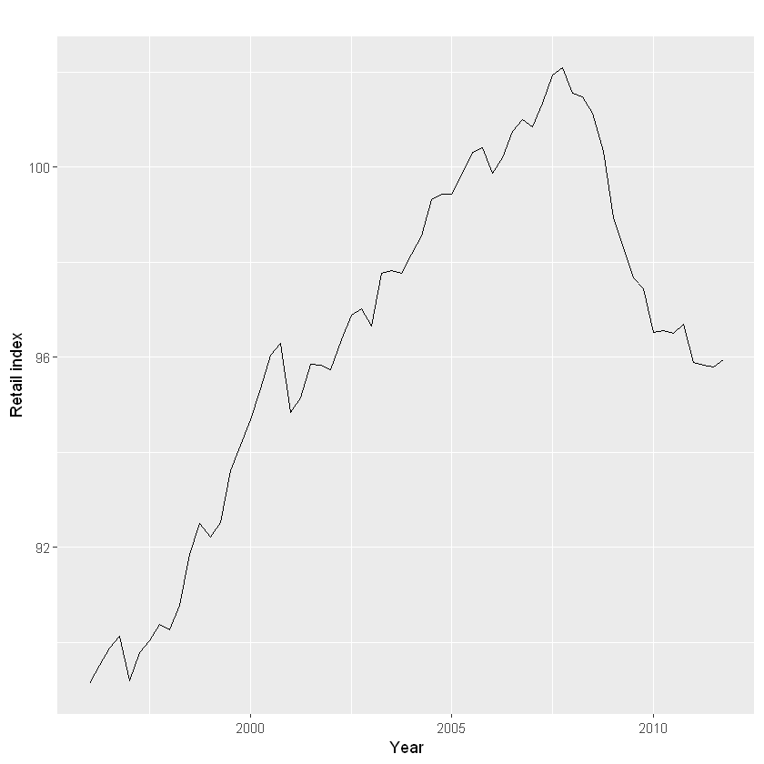

```r
autoplot(euretail) + ylab("Retail index") + xlab("Year")
```

Los datos son claramente no estacionarios, con cierta estacionalidad, por lo que primero tomaremos una diferencia estacional.

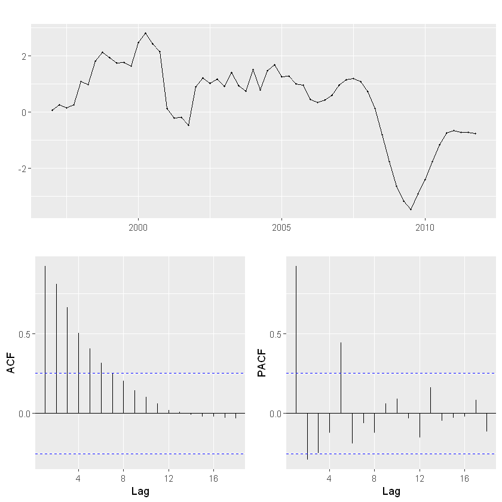

```r
euretail %>% diff(lag=4) %>% ggtsdisplay()
```

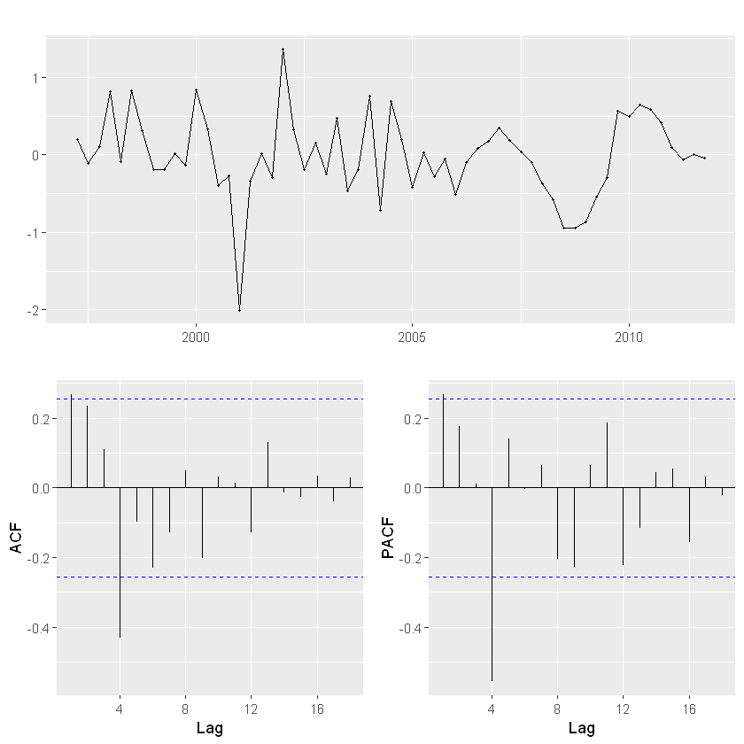

```r
euretail %>% diff(lag=4) %>% diff() %>% ggtsdisplay()
```

Nuestro objetivo ahora es encontrar un modelo ARIMA apropiado basado en el ACF y el PACF. El pico significativo en el retraso 1 en el ACF sugiere un componente MA no estacional (1), y el pico significativo en el retraso 4 en el ACF sugiere un componente MA estacional (1). En consecuencia, comenzamos con un ARIMA (0,1,1) (0,1,1)4, que indica una primera diferencia estacional, y componentes MA (1) no estacionales y estacionales. Los residuos para el modelo ajustado se muestran en la Figura. (Mediante una lógica análoga aplicada al PACF, también podríamos haber comenzado con un ARIMA (1,1,0) (1,1,0)4. )

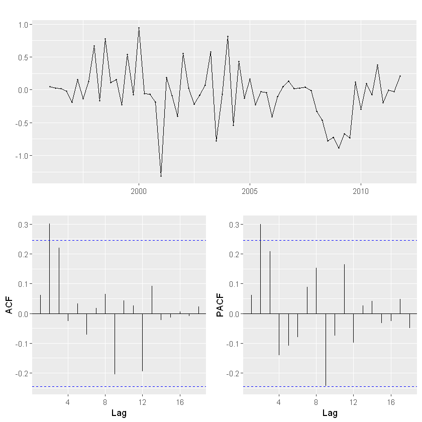

```r
euretail %>%
  Arima(order=c(0,1,1), seasonal=c(0,1,1)) %>%
  residuals() %>% ggtsdisplay()
```

```
	Ljung-Box test

data:  Residuals from ARIMA(0,1,3)(0,1,1)[4]
Q* = 0.51128, df = 4, p-value = 0.9724

Model df: 4.   Total lags used: 8
```

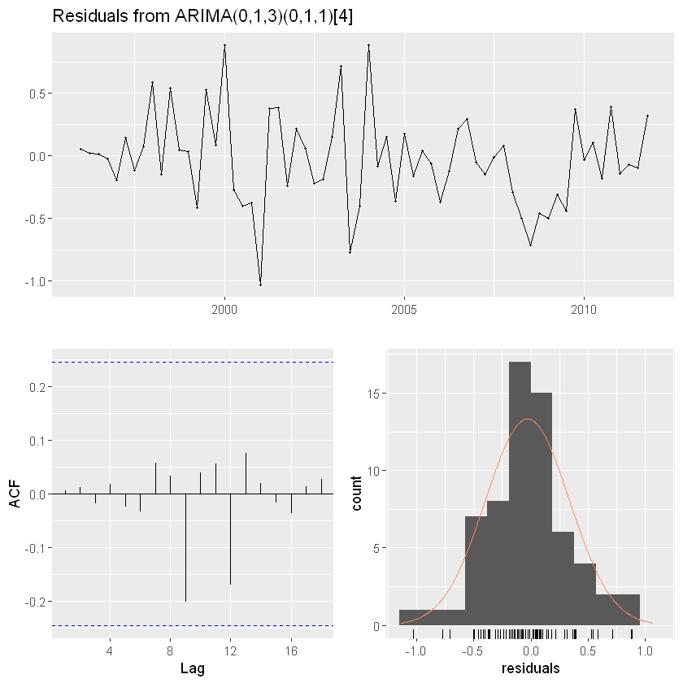

```r
fit3 <- Arima(euretail, order=c(0,1,3), seasonal=c(0,1,1))
checkresiduals(fit3)
```

Por lo tanto, ahora tenemos un modelo ARIMA estacional que pasa los controles requeridos y está listo para el pronóstico. Los pronósticos del modelo para los próximos tres años se muestran en la Figura siguiente. Las previsiones siguen la tendencia reciente en los datos, debido a la doble diferenciación. Los intervalos de predicción grandes y rápidamente crecientes muestran que el índice de comercio minorista podría comenzar a aumentar o disminuir en cualquier momento, mientras que el pronóstico de puntos tiende a la baja, los intervalos de predicción permiten que los datos tengan una tendencia ascendente durante el período de pronóstico.

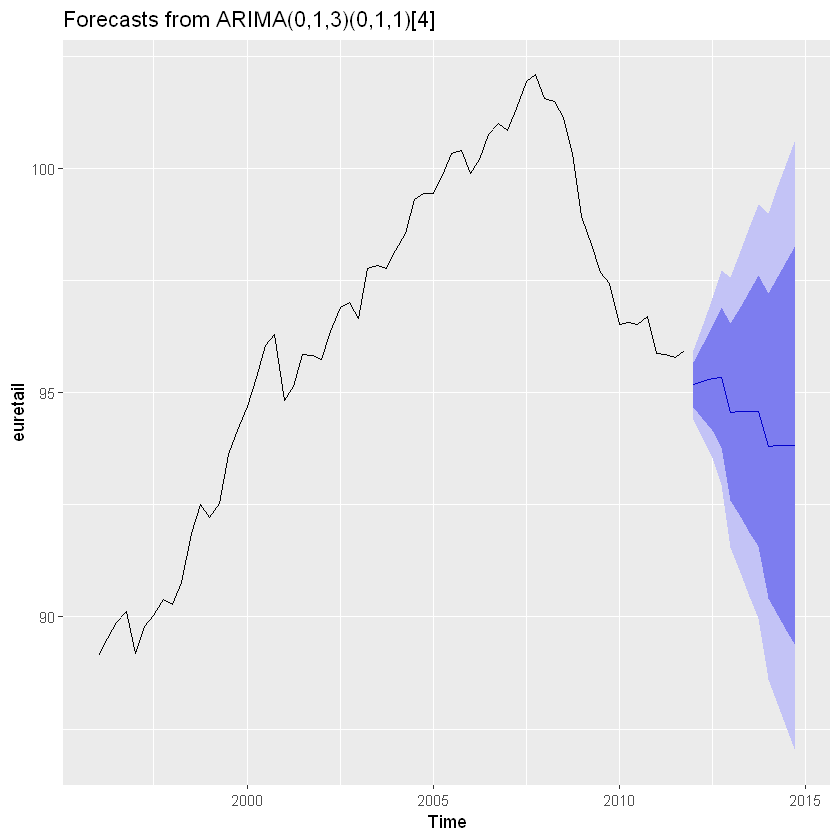

```r
fit3 %>% forecast(h=12) %>% autoplot()
```

Podríamos haber hecho auto.arima() la mayor parte de este trabajo por nosotros. Hubiera dado el mismo resultado.

```r
auto.arima(euretail)
```

```
Series: euretail
ARIMA(0,1,3)(0,1,1)[4]

Coefficients:
         ma1     ma2     ma3     sma1
      0.2630  0.3694  0.4200  -0.6636
s.e.  0.1237  0.1255  0.1294   0.1545

sigma^2 estimated as 0.156:  log likelihood=-28.63
AIC=67.26   AICc=68.39   BIC=77.65
```

La función auto.arima() utiliza nsdiffs() para determinar D(el número de diferencias estacionales para usar), y ndiffs()para determinar d(el número de diferencias ordinarias para usar). La selección de los otros parámetros del modelo ( p,q,Py Q) se determinan minimizando el AICc, como con los modelos ARIMA no estacionales.

**Ejemplo: venta de medicamentos con corticosteroides en Australia**

Nuestro segundo ejemplo es más difícil. Intentaremos pronosticar las ventas mensuales de medicamentos con corticosteroides en Australia. Estos se conocen como medicamentos H02 bajo el esquema de clasificación anatómica terapéutica química.

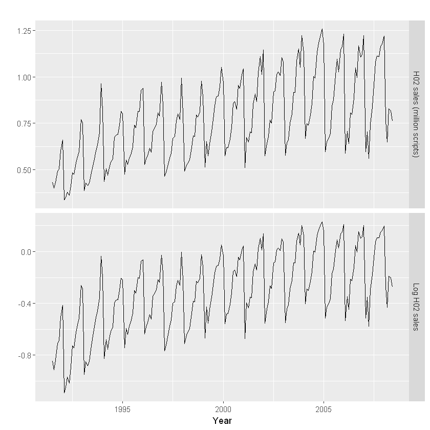

```r
lh02 <- log(h02)
cbind("H02 sales (million scripts)" = h02,
      "Log H02 sales"=lh02) %>%
  autoplot(facets=TRUE) + xlab("Year") + ylab("")
```

Los datos de julio de 1991 a junio de 2008 se representan en la figura. Hay un pequeño aumento en la varianza con el nivel, por lo que tomamos logaritmos para estabilizar la varianza.

Los datos son fuertemente estacionales y obviamente no estacionarios, por lo que se utilizarán las diferencias estacionales. Los datos diferenciados estacionalmente se muestran en la Figura a continuacion. No está claro en este momento si debemos hacer otra diferencia o no. Decidimos no hacerlo, pero la elección no es obvia.

Las últimas observaciones parecen ser diferentes (más variables) de los datos anteriores. Esto puede deberse al hecho de que los datos a veces se revisan cuando las ventas anteriores se informan tarde.

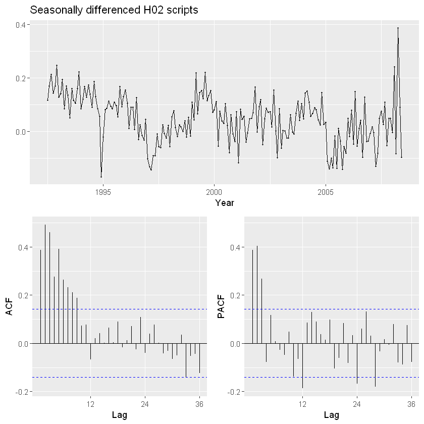

```r
lh02 %>% diff(lag=12) %>%
  ggtsdisplay(xlab="Year",
    main="Seasonally differenced H02 scripts")
```

En las gráficas de los datos diferenciados estacionalmente, hay picos en el PACF en los rezagos 12 y 24, pero nada en los rezagos estacionales en el ACF. Esto puede sugerir un término estacional de AR (2). En los rezagos no estacionales, hay tres picos significativos en el PACF, lo que sugiere un posible término AR (3). El patrón en el ACF no es indicativo de ningún modelo simple.

En consecuencia, este análisis inicial sugiere que un posible modelo para estos datos es un ARIMA (3,0,0) (2,1,0)12. Ajustamos este modelo, junto con algunas variaciones, y calculamos los valores de AICc que se muestran en la siguiente tabla.

```r
#           Modelo	          AICc
#ARIMA (3,0,1) (0,1,2) 12	-485,5
#ARIMA (3,0,1) (1,1,1) 12	-484,2
#ARIMA (3,0,1) (0,1,1) 12	-483,7
#ARIMA (3,0,1) (2,1,0) 12	-476,3
#ARIMA (3,0,0) (2,1,0) 12	-475,1
#ARIMA (3,0,2) (2,1,0) 12	-474,9
#ARIMA (3,0,1) (1,1,0) 12	-463,4
```

De estos modelos, el mejor es el ARIMA (3,0,1) (0,1,2) 12 modelo (es decir, tiene el valor AICc más pequeño).

```r
(fit <- Arima(h02, order=c(3,0,1), seasonal=c(0,1,2), lambda=0))
```

```
Series: h02
ARIMA(3,0,1)(0,1,2)[12]
Box Cox transformation: lambda= 0

Coefficients:
          ar1     ar2     ar3     ma1     sma1     sma2
      -0.1603  0.5481  0.5678  0.3827  -0.5222  -0.1768
s.e.   0.1636  0.0878  0.0942  0.1895   0.0861   0.0872

sigma^2 estimated as 0.004278:  log likelihood=250.04
AIC=-486.08   AICc=-485.48   BIC=-463.28
```

```
	Ljung-Box test

data:  Residuals from ARIMA(3,0,1)(0,1,2)[12]
Q* = 50.712, df = 30, p-value = 0.01045

Model df: 6.   Total lags used: 36
```

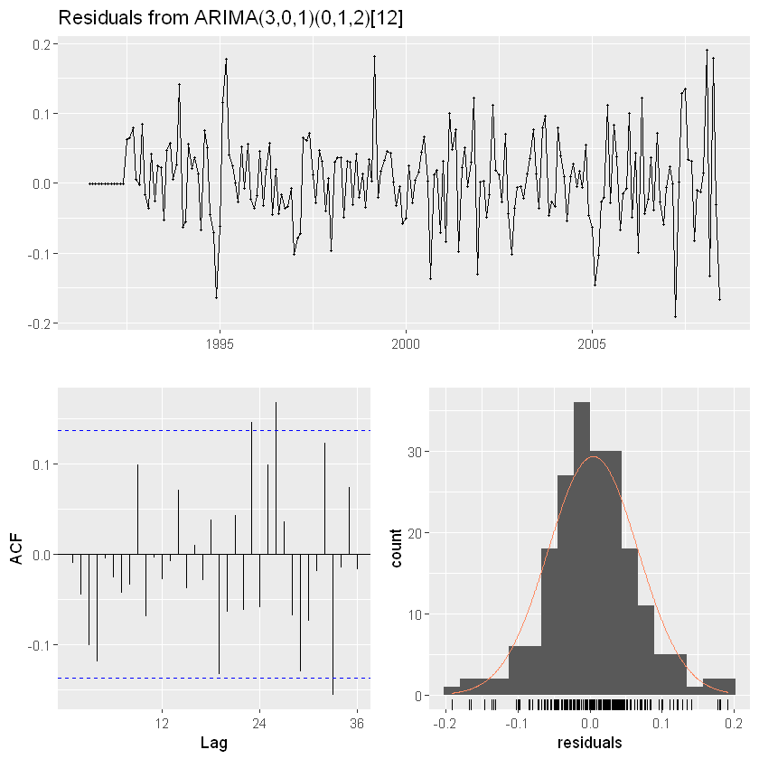

```r
checkresiduals(fit, lag=36)
```

Los residuos de este modelo se muestran en la figura. Hay algunos picos significativos en el ACF, y el modelo falla la prueba de Ljung-Box. El modelo todavía puede usarse para pronosticar, pero los intervalos de predicción pueden no ser precisos debido a los residuos correlacionados.

A continuación, intentaremos usar el algoritmo automático ARIMA. Ejecutar auto.arima()con todos los argumentos en sus valores predeterminados condujo a un ARIMA (2,1,1) (0,1,2)12 modelo. Sin embargo, el modelo todavía falla la prueba de Ljung-Box durante 36 rezagos. A veces, simplemente no es posible encontrar un modelo que pase todas las pruebas.

**Evaluación del conjunto de prueba:**

Compararemos algunos de los modelos ajustados hasta ahora utilizando un conjunto de prueba que consta de los últimos dos años de datos. Por lo tanto, ajustamos los modelos utilizando datos de julio de 1991 a junio de 2006, y pronosticamos las ventas de guiones para julio de 2006 - junio de 2008. Los resultados se resumen en la Tabla:

```r
Modelo	                      RMSE
ARIMA (3,0,1) (0,1,2) 12	0,0622
ARIMA (3,0,1) (1,1,1) 12	0,0630
ARIMA (2,1,3) (0,1,1) 12	0,0634
ARIMA (2,1,1) (0,1,2) 12	0,0634
ARIMA (2,1,2) (0,1,2) 12	0,0635
ARIMA (3,0,3) (0,1,1) 12	0,0637
ARIMA (3,0,1) (0,1,1) 12	0,0644
ARIMA (3,0,2) (0,1,1) 12	0,0644
ARIMA (3,0,2) (2,1,0) 12	0,0645
ARIMA (3,0,1) (2,1,0) 12	0,0646
ARIMA (4,0,2) (0,1,1) 12	0,0648
ARIMA (4,0,3) (0,1,1) 12	0,0648
ARIMA (3,0,0) (2,1,0) 12	0,0661
ARIMA (3,0,1) (1,1,0) 12	0,0679
```

Los modelos elegidos manualmente y con auto.arima() ambos se encuentran en los cuatro modelos principales según sus valores RMSE.

Cuando los modelos se comparan utilizando los valores de AICc, es importante que todos los modelos tengan los mismos órdenes de diferenciación. Sin embargo, cuando se comparan modelos utilizando un conjunto de pruebas, no importa cómo se produjeron los pronósticos: las comparaciones siempre son válidas. Por consiguiente, en la tabla anterior, podemos incluir algunos modelos con solo diferenciación estacional y algunos modelos con diferenciación primera y estacional, mientras que en la tabla anterior que contiene valores AICc, solo comparamos modelos con diferenciación estacional pero no con la primera diferenciación.

Ninguno de los modelos considerados aquí pasa todas las pruebas residuales. En la práctica, normalmente usaríamos el mejor modelo que pudiéramos encontrar, incluso si no pasaba todas las pruebas.

Pronósticos del ARIMA (3,0,1) (0,1,2) 12(que tiene el valor RMSE más bajo en el conjunto de prueba y el mejor valor AICc entre los modelos con solo diferenciación estacional) se muestra en la Figura.

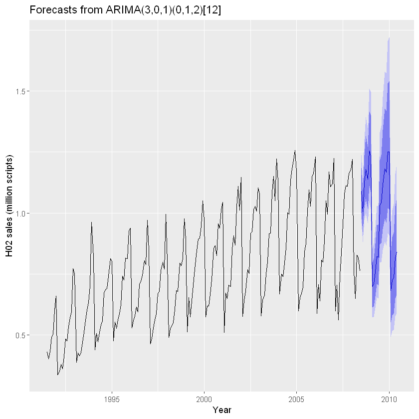

```r
h02 %>%
  Arima(order=c(3,0,1), seasonal=c(0,1,2), lambda=0) %>%
  forecast() %>%
  autoplot() +
    ylab("H02 sales (million scripts)") + xlab("Year")
```

**Bibliografía**

- Forecasting: Principles and Practice Rob J Hyndman y George Athanasopoulos
- Machine Learning with R Cookbook - Second Edition 2017, by AshishSingh Bhatia, Chiu Yu-Wei, Packt Publishing.